# Part 1: Setting up the Project

#### Numerical vs Categorical

Since Price is the dependent variable (y) we will concentrate on the relationships between the categorical variables and Price. We will also consider other key relationships, such as Transmission vs Power. Relationships that are not logical, such as Location vs Seats, can be ignored. This will reduce the analysis from 35 possible combinations to just the important ones.

```python
# Name vs Price
```

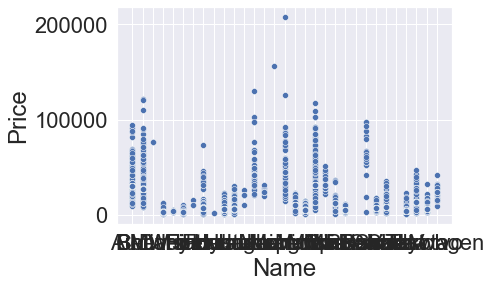

```python
ax = sns.scatterplot(x="Name", y="Price", data=UCD) # this will give us a visual of the data, and will let us see if the two groups appear similar or not
```

```python
# Location vs Price
```

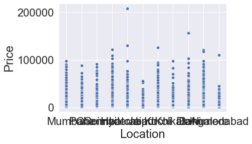

```python
ax = sns.scatterplot(x="Location", y="Price", data=UCD)
```

```python
# KM_Driven vs Price
```

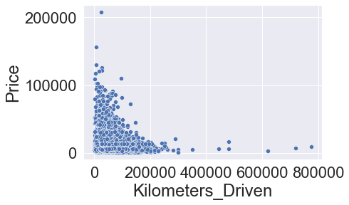

```python
ax = sns.scatterplot(x="Kilometers_Driven", y="Price", data=UCD)
```

```python
# Transmission vs Price
```

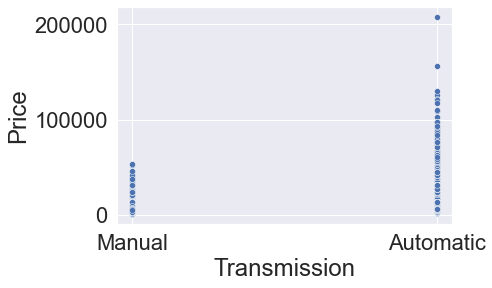

```python
ax = sns.scatterplot(x="Transmission", y="Price", data=UCD)
```

```python
#Owner_Type vs Price
```

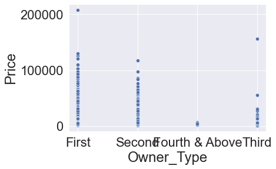

```python
ax = sns.scatterplot(x="Owner_Type", y="Price", data=UCD)
```

```python
# Fuel_Type vs Price
```

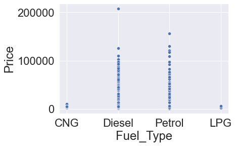

```python
ax = sns.scatterplot(x="Fuel_Type", y="Price", data=UCD)
```

```python
# Transmission vs Power
```

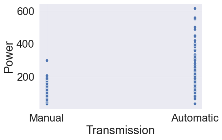

```python
ax = sns.scatterplot(x="Transmission", y="Power", data=UCD)
```

```python
# Transmission vs Engine
```

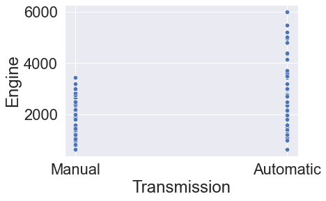

```python
ax = sns.scatterplot(x="Transmission", y="Engine", data=UCD)
```

```python
#Transmission v KM_Driven
```

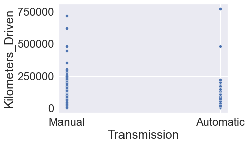

```python
ax = sns.scatterplot(x="Transmission", y="Kilometers_Driven", data=UCD)
```

**Categorical vs Categorical**

```python
#Name vs Location
```

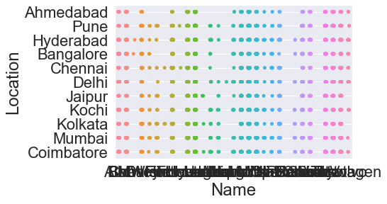

```python
sns.stripplot(data = UCD, x = 'Name', y = 'Location'); # this will graph sex vs smokers
```

[figure not shown]

```python
sns.countplot(data = UCD, x = 'Name', hue = 'Location'); #should give a visual frequency graph of the four groups mentioned above
```

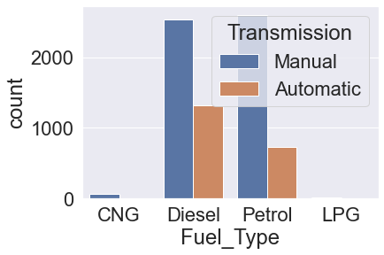

```python
sns.countplot(data = UCD, x = 'Fuel_Type', hue = 'Transmission'); #should give a visual frequency graph of the four groups mentioned above
```

# Part 7: Building the Model

```python
#Defining X and y variables

X = UCD.drop(['Price'], axis=1)
Y = UCD[['Price']]
```

```python
X.head()
```

|  | Name | Location | Year | Kilometers_Driven | Fuel_Type | Transmission | Owner_Type | Mileage | Engine | Power | Seats |
| --- | --- | --- | --- | --- | --- | --- | --- | --- | --- | --- | --- |
| 0 | Maruti | Mumbai | 2010 | 72000 | CNG | Manual | First | 26.60 | 998.0 | 58.16 | 5.0 |
| 1 | Hyundai | Pune | 2015 | 41000 | Diesel | Manual | First | 19.67 | 1582.0 | 126.20 | 5.0 |
| 2 | Honda | Chennai | 2011 | 46000 | Petrol | Manual | First | 18.20 | 1199.0 | 88.70 | 5.0 |
| 3 | Maruti | Chennai | 2012 | 87000 | Diesel | Manual | First | 20.77 | 1248.0 | 88.76 | 7.0 |
| 4 | Audi | Coimbatore | 2013 | 40670 | Diesel | Automatic | Second | 15.20 | 1968.0 | 140.80 | 5.0 |

```python
Y.head()
```

|  | Price |
| --- | --- |
| 0 | 2275.0 |
| 1 | 16250.0 |
| 2 | 5850.0 |
| 3 | 7800.0 |
| 4 | 23062.0 |

```python
print(X.shape)
print(Y.shape)
```

```
(7249, 11)
(7249, 1)
```

### Create Dummy Variables

Values like 'Honda' cannot be read into an equation. Simply names to a numerical placeholder will cause our model to place more emphasis on names assigned a higher value. For example, Honda = 1, Toyota = 10. In order to bypass this problem, we can use dummy variables.

Dummy variables ask whether a feature is 'on' or 'off' using 1 for on and 0 for off. For the Transmission column, it will be split into two separate columns, one for Manual and one for Automatic. If the value in the cell was Manual, it will now correspond to a 1 or 'on' in the Manual column while also being 0 or 'off' in the Automatic column.

```python
X = pd.get_dummies(X, columns=['Name', 'Location', 'Fuel_Type', 'Transmission', 'Owner_Type'], drop_first=True)
X.head()
```

|  | Year | Kilometers_Driven | Mileage | Engine | Power | Seats | Name_BMW | Name_Bentley | Name_Chevrolet | Name_Datsun | ... | Location_Kolkata | Location_Mumbai | Location_Pune | Fuel_Type_Diesel | Fuel_Type_LPG | Fuel_Type_Petrol | Transmission_Manual | Owner_Type_Fourth & Above | Owner_Type_Second | Owner_Type_Third |
| --- | --- | --- | --- | --- | --- | --- | --- | --- | --- | --- | --- | --- | --- | --- | --- | --- | --- | --- | --- | --- | --- |
| 0 | 2010 | 72000 | 26.60 | 998.0 | 58.16 | 5.0 | 0 | 0 | 0 | 0 | ... | 0 | 1 | 0 | 0 | 0 | 0 | 1 | 0 | 0 | 0 |
| 1 | 2015 | 41000 | 19.67 | 1582.0 | 126.20 | 5.0 | 0 | 0 | 0 | 0 | ... | 0 | 0 | 1 | 1 | 0 | 0 | 1 | 0 | 0 | 0 |
| 2 | 2011 | 46000 | 18.20 | 1199.0 | 88.70 | 5.0 | 0 | 0 | 0 | 0 | ... | 0 | 0 | 0 | 0 | 0 | 1 | 1 | 0 | 0 | 0 |
| 3 | 2012 | 87000 | 20.77 | 1248.0 | 88.76 | 7.0 | 0 | 0 | 0 | 0 | ... | 0 | 0 | 0 | 1 | 0 | 0 | 1 | 0 | 0 | 0 |
| 4 | 2013 | 40670 | 15.20 | 1968.0 | 140.80 | 5.0 | 0 | 0 | 0 | 0 | ... | 0 | 0 | 0 | 1 | 0 | 0 | 0 | 0 | 1 | 0 |

5 rows × 53 columns

### Split the data into train and test

```python
from sklearn.model_selection import train_test_split
X_train, X_test, y_train, Y_test = train_test_split(X, Y, test_size=0.3, random_state=42)
```

```python
X_train.head()
```

|  | Year | Kilometers_Driven | Mileage | Engine | Power | Seats | Name_BMW | Name_Bentley | Name_Chevrolet | Name_Datsun | ... | Location_Kolkata | Location_Mumbai | Location_Pune | Fuel_Type_Diesel | Fuel_Type_LPG | Fuel_Type_Petrol | Transmission_Manual | Owner_Type_Fourth & Above | Owner_Type_Second | Owner_Type_Third |
| --- | --- | --- | --- | --- | --- | --- | --- | --- | --- | --- | --- | --- | --- | --- | --- | --- | --- | --- | --- | --- | --- |
| 952 | 2016 | 14930 | 21.40 | 1197.0 | 83.1 | 5.0 | 0 | 0 | 0 | 0 | ... | 0 | 0 | 1 | 0 | 0 | 1 | 1 | 0 | 0 | 0 |
| 2264 | 2009 | 68078 | 19.70 | 796.0 | 46.3 | 5.0 | 0 | 0 | 0 | 0 | ... | 1 | 0 | 0 | 0 | 0 | 1 | 1 | 0 | 0 | 0 |
| 1504 | 2019 | 26013 | 12.65 | 2993.0 | 255.0 | 5.0 | 0 | 0 | 0 | 0 | ... | 0 | 0 | 0 | 1 | 0 | 0 | 0 | 0 | 0 | 0 |
| 7209 | 2013 | 170000 | 22.30 | 1248.0 | 74.0 | 5.0 | 0 | 0 | 0 | 0 | ... | 0 | 0 | 0 | 1 | 0 | 0 | 1 | 0 | 0 | 0 |
| 5538 | 2012 | 81000 | 25.44 | 936.0 | 56.3 | 5.0 | 0 | 0 | 1 | 0 | ... | 0 | 0 | 0 | 1 | 0 | 0 | 1 | 0 | 0 | 0 |

5 rows × 53 columns

### Selecting the Model and Conducting Training

```python
#Fitting linear regression model

from sklearn.linear_model import LinearRegression
linearregression = LinearRegression()
linearregression.fit(X_train, y_train)

print("Intercept of the linear equation:", linearregression.intercept_)
print("\nCOefficients of the equation are:", linearregression.coef_)

from sklearn.metrics import mean_absolute_error, mean_squared_error, r2_score

pred = linearregression.predict(X_test)
```

```
Intercept of the linear equation: [-1997484.60072519]

COefficients of the equation are: [[ 9.98941151e+02 -2.38206817e-02 -1.71463922e+02  2.00019005e+00
   8.36992028e+01  4.24890830e+02 -1.46858373e+03  8.97420851e+03
  -1.60814189e+04 -1.72868361e+04 -1.51170003e+04 -1.71387842e+04
  -1.39945889e+04 -7.71624400e-07 -1.53711674e+04 -1.44812726e+04
  -1.45574576e+04  5.13400396e+03 -1.06447873e+04  8.98829186e+04
   2.07784605e+04 -1.75961265e+04 -1.34696650e+04  5.20020633e+02
   5.34486923e+03 -1.49815081e+04 -1.53474977e+04  5.60243222e-07
   2.02246743e+04 -1.50886232e+04 -1.46932670e+04 -3.19336323e-07
  -1.59553669e+04 -1.22930712e+04 -1.53863796e+04 -8.19138636e+03
   1.81242081e+03  1.80397547e+03  1.85391436e+03 -8.61047548e+02
   1.59337701e+03  1.08184564e+03 -3.21755432e+02 -1.43948081e+03
  -1.13464792e+03  4.58225272e+02  9.65121230e+01  6.67684228e+02
  -1.38112371e+03  1.36702018e+02  1.39426365e+03 -4.41393568e+02
   9.50774693e+01]]
```

### Model Performance

```python
# Mean Absolute Error on test
mean_absolute_error(Y_test, pred)
```

```
3762.9899313318
```

The mean absolute error (MAE) is the simplest regression error metric to understand. We'll calculate the residual for every data point, taking only the absolute value of each so that negative and positive residuals do not cancel out. We then take the average of all these residuals. Effectively, MAE describes the typical magnitude of the residuals.

```python
# RMSE on test data
mean_squared_error(Y_test, pred)**0.5
```

```
6895.175744551495
```

The root mean square error (RMSE) is just like the MAE, but squares the difference before summing them all instead of using the absolute value. And then takes the square root of the value.

```python
# R2 Squared: on test
r2_score(Y_test, pred)
```

```
0.7508498139175053
```

### Conclusion

# Part 8: Improving the Model

```python
UCDI = UCD.copy() #naming a copy UCDI where I stands for Improved
```

```python
UCDI.head()
```

|  | Name | Location | Year | Kilometers_Driven | Fuel_Type | Transmission | Owner_Type | Mileage | Engine | Power | Seats | Price |
| --- | --- | --- | --- | --- | --- | --- | --- | --- | --- | --- | --- | --- |
| 0 | Maruti | Mumbai | 2010 | 72000 | CNG | Manual | First | 26.60 | 998.0 | 58.16 | 5.0 | 2275.0 |
| 1 | Hyundai | Pune | 2015 | 41000 | Diesel | Manual | First | 19.67 | 1582.0 | 126.20 | 5.0 | 16250.0 |
| 2 | Honda | Chennai | 2011 | 46000 | Petrol | Manual | First | 18.20 | 1199.0 | 88.70 | 5.0 | 5850.0 |
| 3 | Maruti | Chennai | 2012 | 87000 | Diesel | Manual | First | 20.77 | 1248.0 | 88.76 | 7.0 | 7800.0 |
| 4 | Audi | Coimbatore | 2013 | 40670 | Diesel | Automatic | Second | 15.20 | 1968.0 | 140.80 | 5.0 | 23062.0 |

First, since there are so few Fourth and Above entries under Owner_Type, lets combine them with Third and rename it Third & Above

```python
UCDI['Owner_Type'] = UCDI['Owner_Type'].map({'First': 'First', 'Second': 'Second', 'Fourth & Above': 'Third & Above', 'Third': 'Third & Above'
                                        })
```

```python
UCDI.Owner_Type.value_counts()
```

```
First            5950
Second           1150
Third & Above     149
Name: Owner_Type, dtype: int64
```

Second, lets convert the Names into 5 different groups: North American (NA), European (EU), East Asian (EA), Indian (IN) or Luxury/Sport (LS)...

```python
UCDI['Name'] = UCDI['Name'].map({'Ford': 'NA', 'Chevrolet': 'NA', 'Jeep': 'NA',
                                 'Volkswagen': 'EU', 'Skoda': 'EU', 'Renault': 'EU', 'Fiat': 'EU', 'Mini': 'EU', 'Volvo': 'EU', 'Smart': 'EU', 'OpelCorsa': 'EU',
                                 'Mitsubishi': 'EA', 'Datsun': 'EA', 'Isuzu': 'EA', 'Honda': 'EA', 'Nissan': 'EA', 'Toyota': 'EA', 'Hyundai': 'EA',
                                 'Maruti': 'IN', 'Mahindra': 'IN', 'Tata': 'IN', 'Force': 'IN', 'Hindustan': 'IN',
                                 'Mercedes-Benz': 'LS', 'BMW': 'LS', 'Audi': 'LS', 'Land': 'LS', 'Jaguar': 'LS', 'Porsche': 'LS', 'Bentley': 'LS', 'Lamborghini': 'LS',
                                        })
```

```python
UCDI.Name.value_counts()
```

```
EA    2764
IN    2007
LS    1114
EU     843
NA     521
Name: Name, dtype: int64
```

Third, lets convert the Locations into 4 different regions: North, South, East, West...

```python
UCDI.Location.value_counts()
```

```
Mumbai        948
Hyderabad     875
Coimbatore    772
Kochi         772
Pune          764
Delhi         660
Kolkata       654
Chennai       590
Jaipur        499
Bangalore     440
Ahmedabad     275
Name: Location, dtype: int64
```

```python
UCDI['Location'] = UCDI['Location'].map({'Delhi': 'North', 'Jaipur': 'North',
                                 'Kochi': 'South', 'Coimbatore': 'South', 'Bangalore': 'South',
                                 'Mumbai': 'West', 'Hyderabad': 'West', 'Ahmedabad': 'West', 'Pune': 'West',
                                 'Kolkata': 'East', 'Chennai': 'East',
                                         })
```

```python
UCDI.Location.value_counts()
```

```
West     2862
South    1984
East     1244
North    1159
Name: Location, dtype: int64
```

```python
UCDI.head()
```

|  | Name | Location | Year | Kilometers_Driven | Fuel_Type | Transmission | Owner_Type | Mileage | Engine | Power | Seats | Price |
| --- | --- | --- | --- | --- | --- | --- | --- | --- | --- | --- | --- | --- |
| 0 | IN | West | 2010 | 72000 | CNG | Manual | First | 26.60 | 998.0 | 58.16 | 5.0 | 2275.0 |
| 1 | EA | West | 2015 | 41000 | Diesel | Manual | First | 19.67 | 1582.0 | 126.20 | 5.0 | 16250.0 |
| 2 | EA | East | 2011 | 46000 | Petrol | Manual | First | 18.20 | 1199.0 | 88.70 | 5.0 | 5850.0 |
| 3 | IN | East | 2012 | 87000 | Diesel | Manual | First | 20.77 | 1248.0 | 88.76 | 7.0 | 7800.0 |
| 4 | LS | South | 2013 | 40670 | Diesel | Automatic | Second | 15.20 | 1968.0 | 140.80 | 5.0 | 23062.0 |

```python
UCDI.isnull().sum()
```

```
Name                 0
Location             0
Year                 0
Kilometers_Driven    0
Fuel_Type            0
Transmission         0
Owner_Type           0
Mileage              0
Engine               0
Power                0
Seats                0
Price                0
dtype: int64
```

Now lets convert Kilometers_Driven to a log scale since it was highly skewed with lots of outliers, but the outliers looked like valid entries. This will cause Kilometers_Driven to convert to a more workable scale and hopefully produce better results...

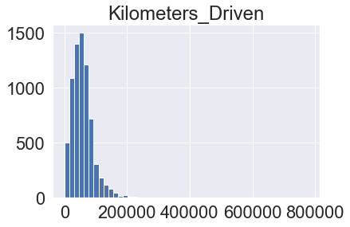

```
0
```

```python
cols_to_log = ['Kilometers_Driven']
for colname in cols_to_log:
    plt.hist(UCDI[colname], bins=50)
    plt.title(colname)
    plt.show()
    print(np.sum(UCDI[colname] <= 0))
```

```python
for colname in cols_to_log:
    UCDI[colname + '_log'] = np.log(UCDI[colname])
UCDI.drop(cols_to_log, axis=1, inplace=True)
```

```python
UCDI.drop(['Power'], axis=1, inplace = True)
```

Now lets try this again...

### Model Building

```python
UCDI.head()
```

|  | Name | Location | Year | Fuel_Type | Transmission | Owner_Type | Mileage | Engine | Seats | Price | Kilometers_Driven_log |
| --- | --- | --- | --- | --- | --- | --- | --- | --- | --- | --- | --- |
| 0 | IN | West | 2010 | CNG | Manual | First | 26.60 | 998.0 | 5.0 | 2275.0 | 11.184421 |
| 1 | EA | West | 2015 | Diesel | Manual | First | 19.67 | 1582.0 | 5.0 | 16250.0 | 10.621327 |
| 2 | EA | East | 2011 | Petrol | Manual | First | 18.20 | 1199.0 | 5.0 | 5850.0 | 10.736397 |
| 3 | IN | East | 2012 | Diesel | Manual | First | 20.77 | 1248.0 | 7.0 | 7800.0 | 11.373663 |
| 4 | LS | South | 2013 | Diesel | Automatic | Second | 15.20 | 1968.0 | 5.0 | 23062.0 | 10.613246 |

```python
#Defining X and y variables
X = UCDI.drop(['Price'], axis=1)
y = UCDI[['Price']]
```

### Create Dummy Variables

```python
X = pd.get_dummies(X, columns=['Name', 'Location', 'Fuel_Type', 'Transmission', 'Owner_Type'], drop_first=True)
```

```python
X.head(1)
```

|  | Year | Mileage | Engine | Seats | Kilometers_Driven_log | Name_EU | Name_IN | Name_LS | Name_NA | Location_North | Location_South | Location_West | Fuel_Type_Diesel | Fuel_Type_LPG | Fuel_Type_Petrol | Transmission_Manual | Owner_Type_Second | Owner_Type_Third & Above |
| --- | --- | --- | --- | --- | --- | --- | --- | --- | --- | --- | --- | --- | --- | --- | --- | --- | --- | --- |
| 0 | 2010 | 26.6 | 998.0 | 5.0 | 11.184421 | 0 | 1 | 0 | 0 | 0 | 0 | 1 | 0 | 0 | 0 | 1 | 0 | 0 |

```python
print(X.shape)
print(y.shape)
```

```
(7249, 18)
(7249, 1)
```

```python
X_train, X_test, y_train, y_test = train_test_split(X, y, test_size=0.3, random_state=42)
```

### Selecting the Model and Conducting Training

```python
#Fitting linear regression model

from sklearn.linear_model import LinearRegression
linearregression = LinearRegression()
linearregression.fit(X_train, y_train)

print("Intercept of the linear equation:", linearregression.intercept_)
print("\nCOefficients of the equation are:", linearregression.coef_)

from sklearn.metrics import mean_absolute_error, mean_squared_error, r2_score

pred = linearregression.predict(X_test)
```

```
Intercept of the linear equation: [-2033536.98030035]

COefficients of the equation are: [[ 1.02006208e+03 -1.27026421e+02  9.50515370e+00 -1.20605242e+03
  -1.60484651e+03  1.22932297e+02  3.14435083e+02  1.74552964e+04
   1.44955874e+02  5.73904751e+02  1.46072352e+03  5.00472979e+02
   4.17004346e+01  2.27499801e+03 -8.51364375e+02 -9.61691404e+02
  -5.04754813e+01  1.61013925e+03]]
```

## Model Performance

```python
# Mean Absolute Error on test
mean_absolute_error(y_test, pred)
```

```
4260.473764495457
```

```python
# RMSE on test data
mean_squared_error(y_test, pred)**0.5
```

```
7307.369824607012
```

```python
# R2 Squared: on test
r2_score(y_test, pred)
```

```
0.720171006199303
```

- R^2 value has dropped from 0.75 to 0.72 which means that in this model independent variables are able to explain only 72% of variances in dependent variable
- Thie model is inferior to the first model, despite being simpler

### Model Building - Excluding Name and Location

```python
#Defining X and y variables
X = UCDI.drop(['Price', 'Name', 'Location'], axis=1)
y = UCDI[['Price']]
```

```python
X = pd.get_dummies(X, columns=['Fuel_Type', 'Transmission', 'Owner_Type'], drop_first=True)
```

```python
X_train, X_test, y_train, y_test = train_test_split(X, y, test_size=0.3, random_state=42)
```

### Selecting the Model and Conducting Training

```python
#Fitting linear regression model

from sklearn.linear_model import LinearRegression
linearregression = LinearRegression()
linearregression.fit(X_train, y_train)

print("Intercept of the linear equation:", linearregression.intercept_)
print("\nCOefficients of the equation are:", linearregression.coef_)

from sklearn.metrics import mean_absolute_error, mean_squared_error, r2_score

pred = linearregression.predict(X_test)
```

```
Intercept of the linear equation: [-1931579.11679869]

COefficients of the equation are: [[  981.13529413  -235.18730239    12.75917353 -3240.56223265
  -2254.04278406    21.66635731  1113.87024213 -3374.00817652
  -7166.64010455   138.54419787  1201.03897935]]
```

## Model Performance

```python
# Mean Absolute Error on test
mean_absolute_error(y_test, pred)
```

```
5282.415424145193
```

```python
# RMSE on test data
mean_squared_error(y_test, pred)**0.5
```

```
8332.773252026682
```

```python
# R2 Squared: on test
r2_score(y_test, pred)
```

```
0.6361271400629517
```

# Add-on: **statsmodels**

- We will use statsmodel to look at ALL the variables to start with and then systematically drop the least helpful variable one at a time until the model stops improving.
- We will use the original UCD dataset because it was superior to the data we tried to improve upon (UCDI - binning and transformations)

```python
# Redifining the variables for the first model...
X = UCD.drop(['Price'], axis=1)
Y = UCD[['Price']]
```

```python
X = pd.get_dummies(X, columns=['Name', 'Location', 'Fuel_Type', 'Transmission', 'Owner_Type'], drop_first=True)
X.head()
```

|  | Year | Kilometers_Driven | Mileage | Engine | Power | Seats | Name_BMW | Name_Bentley | Name_Chevrolet | Name_Datsun | ... | Location_Kolkata | Location_Mumbai | Location_Pune | Fuel_Type_Diesel | Fuel_Type_LPG | Fuel_Type_Petrol | Transmission_Manual | Owner_Type_Fourth & Above | Owner_Type_Second | Owner_Type_Third |
| --- | --- | --- | --- | --- | --- | --- | --- | --- | --- | --- | --- | --- | --- | --- | --- | --- | --- | --- | --- | --- | --- |
| 0 | 2010 | 72000 | 26.60 | 998.0 | 58.16 | 5.0 | 0 | 0 | 0 | 0 | ... | 0 | 1 | 0 | 0 | 0 | 0 | 1 | 0 | 0 | 0 |
| 1 | 2015 | 41000 | 19.67 | 1582.0 | 126.20 | 5.0 | 0 | 0 | 0 | 0 | ... | 0 | 0 | 1 | 1 | 0 | 0 | 1 | 0 | 0 | 0 |
| 2 | 2011 | 46000 | 18.20 | 1199.0 | 88.70 | 5.0 | 0 | 0 | 0 | 0 | ... | 0 | 0 | 0 | 0 | 0 | 1 | 1 | 0 | 0 | 0 |
| 3 | 2012 | 87000 | 20.77 | 1248.0 | 88.76 | 7.0 | 0 | 0 | 0 | 0 | ... | 0 | 0 | 0 | 1 | 0 | 0 | 1 | 0 | 0 | 0 |
| 4 | 2013 | 40670 | 15.20 | 1968.0 | 140.80 | 5.0 | 0 | 0 | 0 | 0 | ... | 0 | 0 | 0 | 1 | 0 | 0 | 0 | 0 | 1 | 0 |

5 rows × 53 columns

```python
# Lets us build linear regression model using statsmodel
import statsmodels.api as sm

X = sm.add_constant(X)
X_train1, X_test, y_train, y_test = train_test_split(X, y, test_size=0.3, random_state=53)

olsmod0 = sm.OLS(y_train, X_train1)
olsres0 = olsmod0.fit()
print(olsres0.summary())
```

```
                            OLS Regression Results
==============================================================================
Dep. Variable:                  Price   R-squared:                       0.765
Model:                            OLS   Adj. R-squared:                  0.763
Method:                 Least Squares   F-statistic:                     321.0
Date:                Sat, 08 May 2021   Prob (F-statistic):               0.00
Time:                        01:31:08   Log-Likelihood:                -51998.
No. Observations:                5074   AIC:                         1.041e+05
Df Residuals:                    5022   BIC:                         1.044e+05
Df Model:                          51
Covariance Type:            nonrobust
=============================================================================================
                                coef    std err          t      P>|t|      [0.025      0.975]
---------------------------------------------------------------------------------------------
const                     -2.024e+06   8.33e+04    -24.297      0.000   -2.19e+06   -1.86e+06
Year                       1010.5024     41.583     24.301      0.000     928.981    1092.024
Kilometers_Driven            -0.0184      0.003     -6.034      0.000      -0.024      -0.012
Mileage                     -82.0164     44.940     -1.825      0.068    -170.119       6.086
Engine                        2.9812      0.526      5.666      0.000       1.950       4.013
Power                        91.0442      5.508     16.529      0.000      80.246     101.842
Seats                        88.9063    190.576      0.467      0.641    -284.705     462.518
Name_BMW                   -993.9219    699.892     -1.420      0.156   -2366.015     378.171
Name_Bentley              -1425.1444   7075.541     -0.201      0.840   -1.53e+04    1.24e+04
Name_Chevrolet            -1.437e+04    935.240    -15.363      0.000   -1.62e+04   -1.25e+04
Name_Datsun               -1.584e+04   2048.983     -7.730      0.000   -1.99e+04   -1.18e+04
Name_Fiat                 -1.365e+04   1546.258     -8.828      0.000   -1.67e+04   -1.06e+04
Name_Force                -1.561e+04   4027.889     -3.875      0.000   -2.35e+04   -7709.904
Name_Ford                 -1.282e+04    761.269    -16.843      0.000   -1.43e+04   -1.13e+04
Name_Hindustan            -1291.2830   4954.468     -0.261      0.794    -1.1e+04    8421.636
Name_Honda                -1.468e+04    694.240    -21.148      0.000    -1.6e+04   -1.33e+04
Name_Hyundai              -1.344e+04    673.385    -19.959      0.000   -1.48e+04   -1.21e+04
Name_Isuzu                -1.675e+04   4038.721     -4.148      0.000   -2.47e+04   -8834.422
Name_Jaguar                8396.2266   1327.335      6.326      0.000    5794.071     1.1e+04
Name_Jeep                 -1.001e+04   1825.682     -5.481      0.000   -1.36e+04   -6428.089
Name_Lamborghini           8.421e+04   7077.442     11.898      0.000    7.03e+04    9.81e+04
Name_Land                   1.77e+04   1155.491     15.320      0.000    1.54e+04       2e+04
Name_Mahindra             -1.573e+04    824.038    -19.088      0.000   -1.73e+04   -1.41e+04
Name_Maruti               -1.206e+04    706.525    -17.069      0.000   -1.34e+04   -1.07e+04
Name_Mercedes-Benz         1578.2877    657.310      2.401      0.016     289.672    2866.903
Name_Mini                  6068.0249   1502.735      4.038      0.000    3122.008    9014.042
```

[output cut: 24 more lines]

```
Transmission_Manual         320.7205    322.068      0.996      0.319    -310.674     952.115
Owner_Type_Fourth & Above  1732.8351   2624.046      0.660      0.509   -3411.441    6877.111
Owner_Type_Second          -514.6043    285.858     -1.800      0.072   -1075.010      45.802
Owner_Type_Third              8.6331    797.541      0.011      0.991   -1554.896    1572.162
==============================================================================
Omnibus:                     4403.738   Durbin-Watson:                   2.033
Prob(Omnibus):                  0.000   Jarque-Bera (JB):           703609.901
Skew:                           3.486   Prob(JB):                         0.00
Kurtosis:                      60.266   Cond. No.                     1.21e+16
==============================================================================

Notes:
[1] Standard Errors assume that the covariance matrix of the errors is correctly specified.
[2] The smallest eigenvalue is 1.7e-19. This might indicate that there are
strong multicollinearity problems or that the design matrix is singular.
```

**Observation**

- P value of a variable indicates if the variable is significant or not. If we consider significance level to be 0.05 (5%) than any variable with p-values less than 0.05 would be considered significant.
- Negative values of coefficient shows that, Price deceases with their increase (ie Mileage).
- Positive values of coefficient shows that, Pricey inceases with their increase (ie Power).
- Lets check for Multicollinearity which affects the p valuesbefore dealing with the p values directly.

## Checking for Multicollinearity

We can check for Multicollinearity by looking at the Variance Inflation factors...

```python
from statsmodels.stats.outliers_influence import variance_inflation_factor
vif_series1 = pd.Series([variance_inflation_factor(X.values,i) for i in range(X.shape[1])],index=X.columns)
print('Series before feature selection: \n\n{}\n'.format(vif_series1))
```

```
Series before feature selection:

const                        750266.662379
Year                              1.976237
Kilometers_Driven                 1.608553
Mileage                           3.759565
Engine                           10.400142
Power                             9.171807
Seats                             2.529741
Name_BMW                          2.084864
Name_Bentley                      1.079389
Name_Chevrolet                    1.853169
Name_Datsun                       1.139834
Name_Fiat                         1.221210
Name_Force                        1.022158
Name_Ford                         2.850431
Name_Hindustan                    1.027890
Name_Honda                        4.670475
Name_Hyundai                      7.231143
Name_Isuzu                        1.041485
Name_Jaguar                       1.187024
Name_Jeep                         1.100480
Name_Lamborghini                  1.043616
Name_Land                         1.239700
Name_Mahindra                     3.112900
Name_Maruti                       8.418595
Name_Mercedes-Benz                2.254628
Name_Mini                         1.128054
Name_Mitsubishi                   1.208047
Name_Nissan                       1.656835
Name_OpelCorsa                         NaN
Name_Porsche                      1.150208
Name_Renault                      1.948540
Name_Skoda                        1.861522
Name_Smart                             NaN
Name_Tata                         2.352453
Name_Toyota                       3.940589
Name_Volkswagen                   2.922809
Name_Volvo                        1.098360
Location_Bangalore                2.483374
Location_Chennai                  2.964413
Location_Coimbatore               3.500264
Location_Delhi                    3.114876
Location_Hyderabad                3.724070
Location_Jaipur                   2.673042
Location_Kochi                    3.497703
Location_Kolkata                  3.119002
Location_Mumbai                   3.945448
Location_Pune                     3.449762
Fuel_Type_Diesel                 31.162859
Fuel_Type_LPG                     1.215410
Fuel_Type_Petrol                 32.161915
Transmission_Manual               2.259330
Owner_Type_Fourth & Above         1.017990
Owner_Type_Second                 1.176124
Owner_Type_Third                  1.117196
dtype: float64
```

- Fuel_Type_Diesel and Fuel_Type_Petrol have a VIF score of much greater than 5
- Clearly these 2 variables are correlated with each other
- However, they are categorical variables, so if one is deleted all Fuel_Types should be deleted

## Removing Multicollinearity

- To remove multicollinearity
  1. Drop every column one by one, that has VIF score greater than 5.
  2. Look at the adjusted R square of all these models
  3. Drop the Variable that makes least change in Adjusted-R square
  4. Check the VIF Scores again
  5. Continue till you get all VIF scores under 5

```python
# we drop the one with the highest vif values and check the Adjusted-R Squared

X_train2 = X_train1
X_train2 = X_train2.drop('Fuel_Type_Petrol', axis=1)
X_train2 = X_train2.drop('Fuel_Type_Diesel', axis=1)
X_train2 = X_train2.drop('Fuel_Type_LPG', axis=1)
X_train2 = X_train2.drop(['Name_OpelCorsa'], axis=1)
X_train2 = X_train2.drop(['Name_Smart'], axis=1)

vif_series2 = pd.Series([variance_inflation_factor(X_train2.values,i) for i in range(X_train2.shape[1])],index=X_train2.columns)
print('Series before feature selection: \n\n{}\n'.format(vif_series2))
```

```
Series before feature selection:

const                        745777.735330
Year                              1.939049
Kilometers_Driven                 1.477032
Mileage                           2.305058
Engine                            8.955153
Power                             9.317847
Seats                             2.410636
Name_BMW                          2.050400
Name_Bentley                      1.054621
Name_Chevrolet                    1.821515
Name_Datsun                       1.132332
Name_Fiat                         1.208435
Name_Force                        1.031128
Name_Ford                         2.903331
Name_Hindustan                    1.040859
Name_Honda                        4.258729
Name_Hyundai                      7.031306
Name_Isuzu                        1.037583
Name_Jaguar                       1.188358
Name_Jeep                         1.127225
Name_Lamborghini                  1.061742
Name_Land                         1.235037
Name_Mahindra                     3.048110
Name_Maruti                       8.155083
Name_Mercedes-Benz                2.296288
Name_Mini                         1.141224
Name_Mitsubishi                   1.232973
Name_Nissan                       1.668664
Name_Porsche                      1.159167
Name_Renault                      1.888270
Name_Skoda                        1.876599
Name_Tata                         2.321437
Name_Toyota                       3.821659
Name_Volkswagen                   2.887107
Name_Volvo                        1.102644
Location_Bangalore                2.623561
Location_Chennai                  3.023858
Location_Coimbatore               3.622766
Location_Delhi                    3.152321
Location_Hyderabad                3.875227
Location_Jaipur                   2.786259
Location_Kochi                    3.548224
Location_Kolkata                  3.236031
Location_Mumbai                   3.992208
Location_Pune                     3.492375
Transmission_Manual               2.249391
Owner_Type_Fourth & Above         1.021049
Owner_Type_Second                 1.185705
Owner_Type_Third                  1.114418
dtype: float64
```

```python
olsmod1 = sm.OLS(y_train, X_train2)
olsres1 = olsmod1.fit()
print(olsres1.summary())
```

```
                            OLS Regression Results
==============================================================================
Dep. Variable:                  Price   R-squared:                       0.765
Model:                            OLS   Adj. R-squared:                  0.763
Method:                 Least Squares   F-statistic:                     340.8
Date:                Sat, 08 May 2021   Prob (F-statistic):               0.00
Time:                        01:31:10   Log-Likelihood:                -52001.
No. Observations:                5074   AIC:                         1.041e+05
Df Residuals:                    5025   BIC:                         1.044e+05
Df Model:                          48
Covariance Type:            nonrobust
=============================================================================================
                                coef    std err          t      P>|t|      [0.025      0.975]
---------------------------------------------------------------------------------------------
const                     -2.027e+06   8.32e+04    -24.354      0.000   -2.19e+06   -1.86e+06
Year                       1010.7447     41.552     24.325      0.000     929.285    1092.205
Kilometers_Driven            -0.0172      0.003     -5.770      0.000      -0.023      -0.011
Mileage                     -27.4288     35.496     -0.773      0.440     -97.016      42.158
Engine                        3.3893      0.483      7.010      0.000       2.441       4.337
Power                        89.4992      5.459     16.396      0.000      78.798     100.201
Seats                       174.1506    185.318      0.940      0.347    -189.153     537.454
Name_BMW                  -1052.2070    699.385     -1.504      0.133   -2423.308     318.894
Name_Bentley              -2529.5868   7052.156     -0.359      0.720   -1.64e+04    1.13e+04
Name_Chevrolet            -1.462e+04    926.951    -15.777      0.000   -1.64e+04   -1.28e+04
Name_Datsun               -1.641e+04   2029.099     -8.087      0.000   -2.04e+04   -1.24e+04
Name_Fiat                 -1.382e+04   1544.424     -8.948      0.000   -1.68e+04   -1.08e+04
Name_Force                -1.584e+04   4026.754     -3.935      0.000   -2.37e+04   -7949.389
Name_Ford                 -1.303e+04    754.615    -17.269      0.000   -1.45e+04   -1.16e+04
Name_Hindustan            -1151.6103   4954.473     -0.232      0.816   -1.09e+04    8561.318
Name_Honda                -1.509e+04    662.745    -22.776      0.000   -1.64e+04   -1.38e+04
Name_Hyundai              -1.375e+04    654.186    -21.022      0.000    -1.5e+04   -1.25e+04
Name_Isuzu                 -1.68e+04   4039.337     -4.160      0.000   -2.47e+04   -8883.292
Name_Jaguar                8362.4045   1327.405      6.300      0.000    5760.112     1.1e+04
Name_Jeep                 -9917.6749   1825.417     -5.433      0.000   -1.35e+04   -6339.061
Name_Lamborghini           8.387e+04   7075.926     11.852      0.000       7e+04    9.77e+04
Name_Land                  1.775e+04   1155.409     15.365      0.000    1.55e+04       2e+04
Name_Mahindra             -1.594e+04    817.531    -19.496      0.000   -1.75e+04   -1.43e+04
Name_Maruti                -1.24e+04    682.411    -18.172      0.000   -1.37e+04   -1.11e+04
Name_Mercedes-Benz         1513.8608    656.552      2.306      0.021     226.733    2800.989
Name_Mini                  5905.6451   1500.861      3.935      0.000    2963.304    8847.986
```

[output cut: 19 more lines]

```
Transmission_Manual         336.5687    322.040      1.045      0.296    -294.771     967.908
Owner_Type_Fourth & Above  1649.2962   2624.248      0.628      0.530   -3495.375    6793.968
Owner_Type_Second          -522.7087    285.866     -1.829      0.068   -1083.130      37.713
Owner_Type_Third            -10.6194    797.518     -0.013      0.989   -1574.102    1552.863
==============================================================================
Omnibus:                     4372.898   Durbin-Watson:                   2.032
Prob(Omnibus):                  0.000   Jarque-Bera (JB):           696961.270
Skew:                           3.445   Prob(JB):                         0.00
Kurtosis:                      60.001   Cond. No.                     6.04e+07
==============================================================================

Notes:
[1] Standard Errors assume that the covariance matrix of the errors is correctly specified.
[2] The condition number is large, 6.04e+07. This might indicate that there are
strong multicollinearity or other numerical problems.
```

- Earlier R-squared remained the same. However, removing Fuel_Type decreases complexity of the model.
- The next highest vif is Power. We know there is strong correlation between Power and Engine so this is probably causing Multicollinearity in our model.
- Power and Engine have vif scores close to 10, we can choose to keep them because they are not too high or we can remove one and see if it improves the model
- To check this let's make a new model after dropping Power

```python
# we drop the one with the highest vif values
X_train3 = X_train2.drop('Power', axis=1)
vif_series3 = pd.Series([variance_inflation_factor(X_train3.values,i) for i in range(X_train3.shape[1])],index=X_train3.columns)
print('Series before feature selection: \n\n{}\n'.format(vif_series3))
```

```
Series before feature selection:

const                        730522.485581
Year                              1.896116
Kilometers_Driven                 1.474352
Mileage                           2.266275
Engine                            3.682474
Seats                             2.242092
Name_BMW                          2.028024
Name_Bentley                      1.036422
Name_Chevrolet                    1.774362
Name_Datsun                       1.121325
Name_Fiat                         1.197329
Name_Force                        1.030096
Name_Ford                         2.671154
Name_Hindustan                    1.028010
Name_Honda                        4.097063
Name_Hyundai                      6.666714
Name_Isuzu                        1.027882
Name_Jaguar                       1.178047
Name_Jeep                         1.127197
Name_Lamborghini                  1.051094
Name_Land                         1.226234
Name_Mahindra                     2.831245
Name_Maruti                       7.670555
Name_Mercedes-Benz                2.293054
Name_Mini                         1.138323
Name_Mitsubishi                   1.178619
Name_Nissan                       1.577404
Name_Porsche                      1.140765
Name_Renault                      1.821557
Name_Skoda                        1.803874
Name_Tata                         2.170485
Name_Toyota                       3.323152
Name_Volkswagen                   2.700020
Name_Volvo                        1.102502
Location_Bangalore                2.623560
Location_Chennai                  3.023648
Location_Coimbatore               3.622717
Location_Delhi                    3.151395
Location_Hyderabad                3.872804
Location_Jaipur                   2.784681
Location_Kochi                    3.548100
Location_Kolkata                  3.235959
Location_Mumbai                   3.991020
Location_Pune                     3.491891
Transmission_Manual               2.215644
Owner_Type_Fourth & Above         1.020926
Owner_Type_Second                 1.185646
Owner_Type_Third                  1.114313
dtype: float64
```

```python
olsmod2 = sm.OLS(y_train, X_train3)
olsres2 = olsmod2.fit()
print(olsres2.summary())
```

```
                            OLS Regression Results
==============================================================================
Dep. Variable:                  Price   R-squared:                       0.752
Model:                            OLS   Adj. R-squared:                  0.750
Method:                 Least Squares   F-statistic:                     325.1
Date:                Sat, 08 May 2021   Prob (F-statistic):               0.00
Time:                        01:31:11   Log-Likelihood:                -52133.
No. Observations:                5074   AIC:                         1.044e+05
Df Residuals:                    5026   BIC:                         1.047e+05
Df Model:                          47
Covariance Type:            nonrobust
=============================================================================================
                                coef    std err          t      P>|t|      [0.025      0.975]
---------------------------------------------------------------------------------------------
const                     -2.223e+06   8.46e+04    -26.285      0.000   -2.39e+06   -2.06e+06
Year                       1112.1178     42.170     26.372      0.000    1029.446    1194.789
Kilometers_Driven            -0.0193      0.003     -6.308      0.000      -0.025      -0.013
Mileage                    -102.9171     36.121     -2.849      0.004    -173.730     -32.104
Engine                        9.4719      0.318     29.768      0.000       8.848      10.096
Seats                      -629.2600    183.422     -3.431      0.001    -988.847    -269.673
Name_BMW                    145.6877    713.850      0.204      0.838   -1253.770    1545.145
Name_Bentley               1.266e+04   7174.891      1.764      0.078   -1406.772    2.67e+04
Name_Chevrolet            -1.707e+04    938.934    -18.180      0.000   -1.89e+04   -1.52e+04
Name_Datsun               -1.969e+04   2072.313     -9.501      0.000   -2.38e+04   -1.56e+04
Name_Fiat                 -1.625e+04   1577.738    -10.297      0.000   -1.93e+04   -1.32e+04
Name_Force                -1.793e+04   4130.577     -4.342      0.000    -2.6e+04   -9835.330
Name_Ford                 -1.653e+04    742.848    -22.253      0.000    -1.8e+04   -1.51e+04
Name_Hindustan            -1.018e+04   5053.282     -2.014      0.044   -2.01e+04    -270.189
Name_Honda                -1.721e+04    667.138    -25.799      0.000   -1.85e+04   -1.59e+04
Name_Hyundai              -1.619e+04    653.751    -24.772      0.000   -1.75e+04   -1.49e+04
Name_Isuzu                -2.321e+04   4126.138     -5.624      0.000   -3.13e+04   -1.51e+04
Name_Jaguar                1.039e+04   1356.389      7.660      0.000    7730.532     1.3e+04
Name_Jeep                 -9768.5832   1873.398     -5.214      0.000   -1.34e+04   -6095.906
Name_Lamborghini           9.548e+04   7225.497     13.215      0.000    8.13e+04     1.1e+05
Name_Land                  1.615e+04   1181.560     13.672      0.000    1.38e+04    1.85e+04
Name_Mahindra             -1.951e+04    808.632    -24.132      0.000   -2.11e+04   -1.79e+04
Name_Maruti               -1.513e+04    679.233    -22.272      0.000   -1.65e+04   -1.38e+04
Name_Mercedes-Benz         1109.8828    673.343      1.648      0.099    -210.163    2429.929
Name_Mini                  4664.9769   1538.370      3.032      0.002    1649.100    7680.854
Name_Mitsubishi           -1.866e+04   1476.276    -12.640      0.000   -2.16e+04   -1.58e+04
```

[output cut: 18 more lines]

```
Transmission_Manual        -310.1710    328.020     -0.946      0.344    -953.234     332.892
Owner_Type_Fourth & Above  2120.1755   2693.098      0.787      0.431   -3159.471    7399.822
Owner_Type_Second          -555.7038    293.376     -1.894      0.058   -1130.849      19.441
Owner_Type_Third            116.5787    818.452      0.142      0.887   -1487.944    1721.101
==============================================================================
Omnibus:                     4553.626   Durbin-Watson:                   2.043
Prob(Omnibus):                  0.000   Jarque-Bera (JB):           672963.252
Skew:                           3.725   Prob(JB):                         0.00
Kurtosis:                      58.925   Cond. No.                     5.98e+07
==============================================================================

Notes:
[1] Standard Errors assume that the covariance matrix of the errors is correctly specified.
[2] The condition number is large, 5.98e+07. This might indicate that there are
strong multicollinearity or other numerical problems.
```

Dropping power reduced both our R-squared and adjusted R-squared. Lets see what happens if we drop Engine instead of Power...

```python
# we drop the one with the highest vif values
X_train4 = X_train2.drop('Engine', axis=1)
vif_series4 = pd.Series([variance_inflation_factor(X_train4.values,i) for i in range(X_train4.shape[1])],index=X_train4.columns)
print('Series before feature selection: \n\n{}\n'.format(vif_series4))
```

```
Series before feature selection:

const                        742583.354110
Year                              1.930714
Kilometers_Driven                 1.457239
Mileage                           2.277488
Power                             3.831618
Seats                             2.057884
Name_BMW                          2.049351
Name_Bentley                      1.054613
Name_Chevrolet                    1.821291
Name_Datsun                       1.132250
Name_Fiat                         1.208175
Name_Force                        1.030842
Name_Ford                         2.869918
Name_Hindustan                    1.035092
Name_Honda                        4.258478
Name_Hyundai                      7.029496
Name_Isuzu                        1.028609
Name_Jaguar                       1.188261
Name_Jeep                         1.127046
Name_Lamborghini                  1.061541
Name_Land                         1.226361
Name_Mahindra                     2.995152
Name_Maruti                       8.151539
Name_Mercedes-Benz                2.281923
Name_Mini                         1.141109
Name_Mitsubishi                   1.196367
Name_Nissan                       1.655959
Name_Porsche                      1.157707
Name_Renault                      1.887676
Name_Skoda                        1.865978
Name_Tata                         2.314307
Name_Toyota                       3.582604
Name_Volkswagen                   2.878398
Name_Volvo                        1.102309
Location_Bangalore                2.623539
Location_Chennai                  3.023851
Location_Coimbatore               3.621885
Location_Delhi                    3.150427
Location_Hyderabad                3.874697
Location_Jaipur                   2.786253
Location_Kochi                    3.547041
Location_Kolkata                  3.236011
Location_Mumbai                   3.988615
Location_Pune                     3.492081
Transmission_Manual               2.249389
Owner_Type_Fourth & Above         1.020764
Owner_Type_Second                 1.185704
Owner_Type_Third                  1.114416
dtype: float64
```

```python
olsmod3 = sm.OLS(y_train, X_train4)
olsres3 = olsmod3.fit()
print(olsres3.summary())
```

```
                            OLS Regression Results
==============================================================================
Dep. Variable:                  Price   R-squared:                       0.763
Model:                            OLS   Adj. R-squared:                  0.761
Method:                 Least Squares   F-statistic:                     343.8
Date:                Sat, 08 May 2021   Prob (F-statistic):               0.00
Time:                        01:31:11   Log-Likelihood:                -52026.
No. Observations:                5074   AIC:                         1.041e+05
Df Residuals:                    5026   BIC:                         1.045e+05
Df Model:                          47
Covariance Type:            nonrobust
=============================================================================================
                                coef    std err          t      P>|t|      [0.025      0.975]
---------------------------------------------------------------------------------------------
const                     -1.989e+06   8.35e+04    -23.832      0.000   -2.15e+06   -1.83e+06
Year                        991.6472     41.661     23.803      0.000     909.974    1073.320
Kilometers_Driven            -0.0148      0.003     -4.968      0.000      -0.021      -0.009
Mileage                     -54.6422     35.451     -1.541      0.123    -124.142      14.858
Power                       118.8622      3.517     33.795      0.000     111.967     125.757
Seats                       671.1067    172.041      3.901      0.000     333.832    1008.382
Name_BMW                  -1163.1005    702.547     -1.656      0.098   -2540.400     214.199
Name_Bentley              -2400.4274   7085.827     -0.339      0.735   -1.63e+04    1.15e+04
Name_Chevrolet             -1.47e+04    931.323    -15.780      0.000   -1.65e+04   -1.29e+04
Name_Datsun               -1.653e+04   2038.720     -8.108      0.000   -2.05e+04   -1.25e+04
Name_Fiat                 -1.398e+04   1551.636     -9.009      0.000    -1.7e+04   -1.09e+04
Name_Force                -1.537e+04   4045.432     -3.800      0.000   -2.33e+04   -7442.252
Name_Ford                 -1.246e+04    753.845    -16.534      0.000   -1.39e+04    -1.1e+04
Name_Hindustan             1433.6577   4964.336      0.289      0.773   -8298.605    1.12e+04
Name_Honda                -1.506e+04    665.892    -22.615      0.000   -1.64e+04   -1.38e+04
Name_Hyundai              -1.383e+04    657.227    -21.036      0.000   -1.51e+04   -1.25e+04
Name_Isuzu                -1.417e+04   4041.049     -3.506      0.000   -2.21e+04   -6246.586
Name_Jaguar                8278.3887   1333.693      6.207      0.000    5663.769    1.09e+04
Name_Jeep                 -1.008e+04   1833.994     -5.496      0.000   -1.37e+04   -6483.519
Name_Lamborghini           8.455e+04   7109.062     11.893      0.000    7.06e+04    9.85e+04
Name_Land                  1.843e+04   1156.845     15.933      0.000    1.62e+04    2.07e+04
Name_Mahindra             -1.518e+04    814.270    -18.646      0.000   -1.68e+04   -1.36e+04
Name_Maruti                -1.25e+04    685.523    -18.235      0.000   -1.38e+04   -1.12e+04
Name_Mercedes-Benz         1877.8958    657.622      2.856      0.004     588.669    3167.122
Name_Mini                  6011.4272   1507.955      3.986      0.000    3055.177    8967.678
Name_Mitsubishi           -1.182e+04   1456.163     -8.116      0.000   -1.47e+04   -8963.587
```

[output cut: 18 more lines]

```
Transmission_Manual         338.6953    323.579      1.047      0.295    -295.660     973.051
Owner_Type_Fourth & Above  1342.3245   2636.420      0.509      0.611   -3826.208    6510.857
Owner_Type_Second          -525.0041    287.231     -1.828      0.068   -1088.103      38.095
Owner_Type_Third            -18.1574    801.328     -0.023      0.982   -1589.109    1552.794
==============================================================================
Omnibus:                     4332.855   Durbin-Watson:                   2.025
Prob(Omnibus):                  0.000   Jarque-Bera (JB):           679163.498
Skew:                           3.395   Prob(JB):                         0.00
Kurtosis:                      59.270   Cond. No.                     6.03e+07
==============================================================================

Notes:
[1] Standard Errors assume that the covariance matrix of the errors is correctly specified.
[2] The condition number is large, 6.03e+07. This might indicate that there are
strong multicollinearity or other numerical problems.
```

- Now the above model only has vifs in the Name variable, but as a categorical variable, I cannot delete one without deleting the whole group. Therefore, I will ignore these variables for now
- There is no other multicollinearity, so we can look at p values of predictor variables to check their significance

**Observations**

```python
X_train5 = X_train4.drop(['Owner_Type_Second'], axis=1)
X_train5 = X_train5.drop(['Owner_Type_Third'], axis=1)
X_train5 = X_train5.drop(['Owner_Type_Fourth & Above'], axis=1)
```

```python
olsmod3 = sm.OLS(y_train, X_train5)
olsres3 = olsmod3.fit()
print(olsres3.summary())
```

```
                            OLS Regression Results
==============================================================================
Dep. Variable:                  Price   R-squared:                       0.763
Model:                            OLS   Adj. R-squared:                  0.760
Method:                 Least Squares   F-statistic:                     367.1
Date:                Sat, 08 May 2021   Prob (F-statistic):               0.00
Time:                        01:31:12   Log-Likelihood:                -52027.
No. Observations:                5074   AIC:                         1.041e+05
Df Residuals:                    5029   BIC:                         1.044e+05
Df Model:                          44
Covariance Type:            nonrobust
=======================================================================================
                          coef    std err          t      P>|t|      [0.025      0.975]
---------------------------------------------------------------------------------------
const               -2.021e+06   7.97e+04    -25.352      0.000   -2.18e+06   -1.86e+06
Year                 1007.5309     39.821     25.301      0.000     929.464    1085.598
Kilometers_Driven      -0.0148      0.003     -4.955      0.000      -0.021      -0.009
Mileage               -53.6868     35.446     -1.515      0.130    -123.177      15.804
Power                 118.9502      3.517     33.824      0.000     112.056     125.844
Seats                 676.0798    171.814      3.935      0.000     339.250    1012.909
Name_BMW            -1146.8587    702.533     -1.632      0.103   -2524.130     230.413
Name_Bentley        -2683.4560   7084.617     -0.379      0.705   -1.66e+04    1.12e+04
Name_Chevrolet      -1.466e+04    930.958    -15.748      0.000   -1.65e+04   -1.28e+04
Name_Datsun         -1.645e+04   2038.423     -8.069      0.000   -2.04e+04   -1.25e+04
Name_Fiat           -1.396e+04   1550.836     -9.002      0.000    -1.7e+04   -1.09e+04
Name_Force           -1.53e+04   4045.502     -3.782      0.000   -2.32e+04   -7368.309
Name_Ford           -1.243e+04    753.038    -16.506      0.000   -1.39e+04    -1.1e+04
Name_Hindustan       1550.5426   4955.863      0.313      0.754   -8165.109    1.13e+04
Name_Honda          -1.502e+04    665.537    -22.570      0.000   -1.63e+04   -1.37e+04
Name_Hyundai        -1.379e+04    656.894    -20.985      0.000   -1.51e+04   -1.25e+04
Name_Isuzu          -1.411e+04   4041.231     -3.492      0.000    -2.2e+04   -6188.115
Name_Jaguar          8312.0294   1333.679      6.232      0.000    5697.437    1.09e+04
Name_Jeep           -1.003e+04   1833.853     -5.471      0.000   -1.36e+04   -6438.350
Name_Lamborghini     8.468e+04   7067.921     11.980      0.000    7.08e+04    9.85e+04
Name_Land            1.839e+04   1156.754     15.902      0.000    1.61e+04    2.07e+04
Name_Mahindra       -1.515e+04    813.972    -18.614      0.000   -1.67e+04   -1.36e+04
Name_Maruti         -1.245e+04    684.919    -18.173      0.000   -1.38e+04   -1.11e+04
Name_Mercedes-Benz   1910.7599    657.442      2.906      0.004     621.888    3199.632
Name_Mini            5976.5182   1507.790      3.964      0.000    3020.593    8932.443
Name_Mitsubishi     -1.174e+04   1454.191     -8.075      0.000   -1.46e+04   -8891.362
```

[output cut: 15 more lines]

```
Location_Kolkata    -1305.6709    601.491     -2.171      0.030   -2484.855    -126.487
Location_Mumbai     -1207.2181    579.497     -2.083      0.037   -2343.284     -71.152
Location_Pune         427.7224    593.597      0.721      0.471    -735.987    1591.432
Transmission_Manual   335.5322    323.584      1.037      0.300    -298.833     969.897
==============================================================================
Omnibus:                     4330.494   Durbin-Watson:                   2.026
Prob(Omnibus):                  0.000   Jarque-Bera (JB):           678557.579
Skew:                           3.392   Prob(JB):                         0.00
Kurtosis:                      59.245   Cond. No.                     5.76e+07
==============================================================================

Notes:
[1] Standard Errors assume that the covariance matrix of the errors is correctly specified.
[2] The condition number is large, 5.76e+07. This might indicate that there are
strong multicollinearity or other numerical problems.
```